# Fitness Quality Prediction

**Prediction on Test Data**  
Now we can use the fitted model for Random Forest, to predict the classe for each of the 20 samples in the test data set.

```r
# Make final predction on testing data set
stats::predict( modFit_rf, newdata = pml_testing, type="class")
```

```
##  1  2  3  4  5  6  7  8  9 10 11 12 13 14 15 16 17 18 19 20
##  B  A  B  A  A  E  D  B  A  A  B  C  B  A  E  E  A  B  B  B
## Levels: A B C D E
```

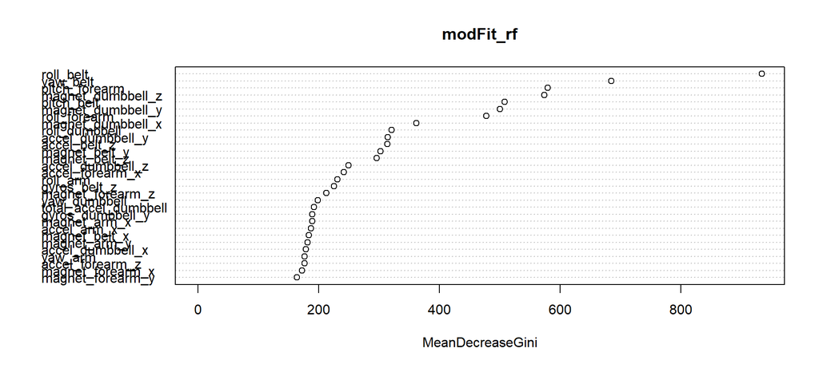

**Plotting the complicated of Support Vector Machine SVM Classification Plot**  
This section is to demonstrate the complexities of the Support Vector Machine SVM Classification Plot. Even though we did not choose the svm fitted model, it is worth seeing. Because of the many factors used in our model, we would need many different plots to be of any use, and that is another reason not to use SVM for this project. This is only one plot, with two predictors on x and y axis, respectively.

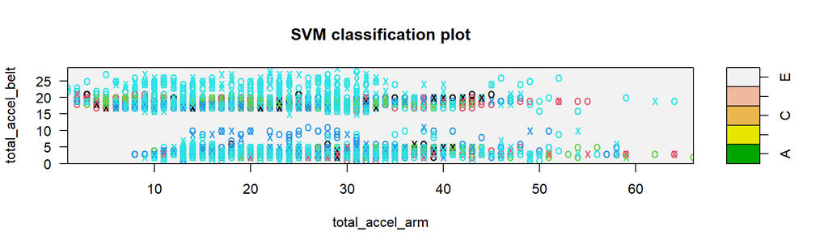

**Plotting the Worst Model: Recursive Partitioning and Regression Trees**  
This section gives us a visual of the worst model, Recursive Partitioning and Regression Trees, which had an accuracy of only approx 75%. If you enlarged this model, it would be possible to follow the tree downard, until arriving at the nodes on the bottom, which represent the classe(s)

[figure not shown]